# Lesson 2: NumPy and Pandas for 1D Data

## 01 - Introduction

- Will get familiar with 2 libraries - numpy and pandas
- Writing Data Analysis code will be much easier.
- Code runs faster
- Analyse one dimensional data

## 02 - Gapminder Data

The data in this lesson was obtained from the site [gapminder.org](http://www.gapminder.org/data/). The variables included are:

- Aged 15+ Employment Rate (%)
- Life Expectancy (years)
- GDP/capita (US$, inflation adjusted)
- Primary school completion (% of boys)
- Primary school completion (% of girls)

## 04 - One-Dimensional Data in NumPy and Pandas

```python
import pandas as pd
```

- Importing it takes some time
- Has many functions like `read_csv` and `uniq` that help a lot

```python
import numpy as np
```

## 05 - NumPy Arrays

- Both Pandas and NumPy have special data structures for 1 D data

[figure not shown]

- Numpy array is similar to Python list
- Similarities
  - Access element by index
  - Access a range of elements
  - Use loops
- Differences
  - Each element should have same type
  - Can have different types but it was designed for single data type
  - Convenient functions like `mean` and `std`

```python
employments = pd.read_csv('employment_above_15.csv')
```

```python
employments[0:5]
```

|  | Country | 1991 | 1992 | 1993 | 1994 | 1995 | 1996 | 1997 | 1998 | 1999 | 2000 | 2001 | 2002 | 2003 | 2004 | 2005 | 2006 | 2007 |
| --- | --- | --- | --- | --- | --- | --- | --- | --- | --- | --- | --- | --- | --- | --- | --- | --- | --- | --- |
| 0 | Afghanistan | 56.700001 | 56.500000 | 56.599998 | 56.200001 | 56.200001 | 56.099998 | 56.200001 | 56.200001 | 56.099998 | 56.099998 | 56.500000 | 56.400002 | 54.400002 | 56.000000 | 54.000000 | 56.000000 | 55.700001 |
| 1 | Albania | 52.700001 | 52.299999 | 52.400002 | 52.700001 | 52.799999 | 52.599998 | 52.400002 | 52.099998 | 52.099998 | 51.900002 | 51.799999 | 51.799999 | 51.799999 | 51.700001 | 51.500000 | 51.400002 | 51.400002 |
| 2 | Algeria | 39.400002 | 38.900002 | 39.400002 | 39.400002 | 38.099998 | 38.900002 | 39.700001 | 39.500000 | 39.400002 | 38.599998 | 40.400002 | 41.500000 | 42.799999 | 46.400002 | 48.000000 | 50.000000 | 50.500000 |
| 3 | Angola | 75.800003 | 75.800003 | 75.500000 | 75.900002 | 75.800003 | 75.900002 | 75.699997 | 75.599998 | 75.599998 | 75.500000 | 75.500000 | 75.599998 | 75.500000 | 75.500000 | 75.599998 | 75.500000 | 75.699997 |
| 4 | Argentina | 53.599998 | 53.799999 | 53.700001 | 53.799999 | 53.500000 | 54.400002 | 54.900002 | 55.000000 | 54.900002 | 55.500000 | 55.599998 | 55.400002 | 57.299999 | 57.700001 | 58.099998 | 58.400002 | 58.400002 |

```python
#Selecting a column and displaying its first 5 elements
employments.get('1991')[0:5]
```

```
0    56.700001
1    52.700001
2    39.400002
3    75.800003
4    53.599998
Name: 1991, dtype: float64
```

```python
employments.get('Country')[0:5]
```

```
0    Afghanistan
1        Albania
2        Algeria
3         Angola
4      Argentina
Name: Country, dtype: object
```

```python
def max_employment(countries, employment):
    i = employment.argmax()
    return (countries[i], employment[i])
```

```python
max_employment(employments.get('Country'), employments.get('2007'))
```

```
('Burundi', 83.199996948199995)
```

Let's look at the element type of few array which numpy calls `dtype`

```python
countries = np.array(['Afghanistan','Albania','Algeria','Angola','Argentina','Armenia'])
employment = np.array([56.700001, 52.700001, 39.400002, 75.800003, 53.599998])

print countries.dtype
print employment.dtype

print np.array([0, 1, 2, 3]).dtype
print np.array([True, False, True]).dtype
print np.array(['AL', 'AK']).dtype
```

```
|S11
float64
int64
bool
|S2
```

`|S11` means String with maximum length 11.

```python
print employment.mean()
print employment.std()
print employment.max()
print employment.sum()
```

```
55.640001
11.6969402871
75.800003
278.200005
```

## 07 - Vectorized Operations

- Numpy supports Vectorized operations
- A vector is a list of numbers

[figure not shown]

- Addition of 2 vectors can be done in several ways. Different languages implement it differently

[figure not shown]

- In case of NumPy it is an element wise addition

```python
np.array([1, 2, 3]) + np.array([4, 5, 6])
```

```
array([5, 7, 9])
```

## 09 - Multiplying by a Scalar

- Multiplying by Scalar is scalar multiplied with each element of the array

[figure not shown]

```python
np.array([1, 2, 3]) * 3
```

```
array([3, 6, 9])
```

## 11 - Calculate Overall Completion Rate

### More vectorized operations

```python
np.array([1, 2, 3]) + np.array([4, 5, 6])
```

```
array([5, 7, 9])
```

```python
np.array([1, 2, 3]) + 1
```

```
array([2, 3, 4])
```

```python
np.array([1, 2, 3]) - np.array([7, 10, 15])
```

```
array([ -6,  -8, -12])
```

```python
np.array([1, 2, 3]) - 1
```

```
array([0, 1, 2])
```

```python
np.array([1, 2, 3]) * np.array([4, 5, 6])
```

```
array([ 4, 10, 18])
```

```python
np.array([1, 2, 3]) * np.array([2])
```

```
array([2, 4, 6])
```

```python
#Throws error
#np.array([1, 2, 3]) * np.array([2, 3])
```

```python
np.array([2, 3]) ** np.array([2, 3])
```

```
array([ 4, 27])
```

```python
np.array([5, 6]) ** 2
```

```
array([25, 36])
```

[figure not shown]

See [this article](https://en.wikipedia.org/wiki/Bitwise_operation) for more information about bitwise operations.

In NumPy, `a & b` performs a bitwise and of a and b. This is not necessarily the same as a logical and, if you wanted to see if matching terms in two integer vectors were non-zero. However, if `a` and `b` are both arrays of booleans, rather than integers, bitwise and and logical and are the same thing. If you want to perform a logical and on integer vectors, then you can use the NumPy function `np.logical_and(a, b)` or convert them into boolean vectors first.

Similarly, `a | b` performs a bitwise or, and `~a` performs a bitwise not. However, if your arrays contain booleans, these will be the same as performing logical or and logical not. NumPy also has similar functions for performing these logical operations on integer-valued arrays.

In the solution, we may want to `/ (2.)` instead of just `/ (2)` . This is because in Python 2, dividing an integer by another integer (2) drops fractions, so if our inputs are also integers, we may end up losing information. If we divide by a float (2.) then we will definitely retain decimal values.

```python
female_completion = pd.read_csv('female_completion_rate.csv')
male_completion = pd.read_csv('male_completion_rate.csv')
```

```python
female_completion[0:5]
```

|  | Country | 1970 | 1971 | 1972 | 1973 | 1974 | 1975 | 1976 | 1977 | 1978 | ... | 2002 | 2003 | 2004 | 2005 | 2006 | 2007 | 2008 | 2009 | 2010 | 2011 |
| --- | --- | --- | --- | --- | --- | --- | --- | --- | --- | --- | --- | --- | --- | --- | --- | --- | --- | --- | --- | --- | --- |
| 0 | Abkhazia | NaN | NaN | NaN | NaN | NaN | NaN | NaN | NaN | NaN | ... | NaN | NaN | NaN | NaN | NaN | NaN | NaN | NaN | NaN | NaN |
| 1 | Afghanistan | NaN | NaN | NaN | NaN | 4.19285 | NaN | NaN | 5.14529 | 5.91965 | ... | NaN | NaN | NaN | 18.74188 | NaN | NaN | NaN | NaN | NaN | NaN |
| 2 | Akrotiri and Dhekelia | NaN | NaN | NaN | NaN | NaN | NaN | NaN | NaN | NaN | ... | NaN | NaN | NaN | NaN | NaN | NaN | NaN | NaN | NaN | NaN |
| 3 | Albania | NaN | NaN | NaN | NaN | NaN | NaN | NaN | NaN | NaN | ... | NaN | 100.27718 | 97.70814 | NaN | NaN | NaN | 90.41091 | 89.76010 | 86.01452 | 89.53901 |
| 4 | Algeria | NaN | NaN | 30.90031 | 33.02938 | 34.32702 | 39.7942 | 45.24156 | 48.22515 | 50.49138 | ... | 90.09179 | 91.27633 | 93.30839 | 94.21432 | NaN | 97.35583 | 109.72854 | 95.13346 | 95.87439 | 94.20928 |

5 rows × 43 columns

```python
male_completion[0:5]
```

|  | Country | 1970 | 1971 | 1972 | 1973 | 1974 | 1975 | 1976 | 1977 | 1978 | ... | 2002 | 2003 | 2004 | 2005 | 2006 | 2007 | 2008 | 2009 | 2010 | 2011 |
| --- | --- | --- | --- | --- | --- | --- | --- | --- | --- | --- | --- | --- | --- | --- | --- | --- | --- | --- | --- | --- | --- |
| 0 | Abkhazia | NaN | NaN | NaN | NaN | NaN | NaN | NaN | NaN | NaN | ... | NaN | NaN | NaN | NaN | NaN | NaN | NaN | NaN | NaN | NaN |
| 1 | Afghanistan | NaN | NaN | NaN | NaN | 26.23178 | NaN | NaN | 26.73849 | 29.07336 | ... | NaN | NaN | NaN | 48.36070 | NaN | NaN | NaN | NaN | NaN | NaN |
| 2 | Akrotiri and Dhekelia | NaN | NaN | NaN | NaN | NaN | NaN | NaN | NaN | NaN | ... | NaN | NaN | NaN | NaN | NaN | NaN | NaN | NaN | NaN | NaN |
| 3 | Albania | NaN | NaN | NaN | NaN | NaN | NaN | NaN | NaN | NaN | ... | NaN | 101.90853 | 99.10666 | NaN | NaN | NaN | 89.44897 | 88.83622 | 86.49044 | 88.18113 |
| 4 | Algeria | NaN | NaN | 55.3917 | 57.41252 | 60.71733 | 66.29215 | 72.58079 | 75.04380 | 77.39284 | ... | 90.34439 | 92.04006 | 92.68131 | 94.66572 | NaN | 95.47622 | 121.33472 | 93.16440 | 96.09082 | 94.51607 |

5 rows × 43 columns

```python
female = np.array([56.0, 23.0, 65.0])
male = np.array([23.0, 45.0, 22.0])
```

```python
def overall_completion_rate(female_completion, male_completion):
    return (female_completion + male_completion) / 2
```

```python
overall_completion_rate(female, male)
```

```
array([ 39.5,  34. ,  43.5])
```

## 13 - Standardizing Data

- How does one data point compare to other data point?
- One way to do this is to convert the data point to number of standard deviations from the mean

```python
def standardize_data(values):
    return (values - values.mean()) / values.std()
```

## 15 - NumPy Index Arrays

[figure not shown]

```python
def mean_time_for_paid_students(time_spent, days_to_cancel):
    return time_spent[days_to_cancel >= 7].mean()
```

## 17 - + vs +=

```python
a = np.array([1, 2, 3, 4])
b = a
a += np.array([1, 1, 1, 1]) #Difference here
print b
```

```
[2 3 4 5]
```

[figure not shown]

```python
a = np.array([1, 2, 3, 4])
b = a
a = a + np.array([1, 1, 1, 1]) #Difference here
print b
```

```
[1 2 3 4]
```

[figure not shown]

## 19 - In-Place vs Not In-Place

- `+=` operates in-place while `+` does not

```python
a = np.array([1, 2, 3, 4, 5])
slice = a[:3]
slice[0] = 100

a
```

```
array([100,   2,   3,   4,   5])
```

- `slice` refers to view of original array

## 21 - Pandas Series

[figure not shown]

```python
def variable_correlation(variable1, variable2):
    both_above = (variable1 > variable1.mean()) & \
                 (variable2 > variable2.mean())
    both_below = (variable1 < variable1.mean()) & \
                 (variable2 < variable2.mean())

    is_same_direction = both_above | both_below
    num_same_direction = is_same_direction.sum()

    num_different_direction = len(variable1) - num_same_direction

    return (num_same_direction, num_different_direction)
```

## 23 - Series Indexes

```python
s = pd.Series([1, 2, 3, 4])
```

```python
s.describe()
```

```
count    4.000000
mean     2.500000
std      1.290994
min      1.000000
25%      1.750000
50%      2.500000
75%      3.250000
max      4.000000
dtype: float64
```

```python
countries = np.array(['Albania', 'Algeria', 'Andorra', 'Angola'])
life_expectancy = np.array([74.7, 75., 83.4, 57.6])

life_expectancy
```

```
array([ 74.7,  75. ,  83.4,  57.6])
```

Some people call `countries[0]` as indexing into array. But the instructor uses position 0 to avoid confusion. This is because in Pandas index and postion are not the same thing

```python
life_expectancy = pd.Series([74.7, 75., 83.4, 57.6],
                           index = ['Albania',
                                    'Algeria',
                                    'Andorra',
                                    'Angola'])

life_expectancy
```

```
Albania    74.7
Algeria    75.0
Andorra    83.4
Angola     57.6
dtype: float64
```

- NumPy arrays are souped-up version of Python lists
- Pandas Series is like a cross between a list and a dictionary

```python
#Access by index
life_expectancy.loc['Angola']
```

```
57.600000000000001
```

```python
#If we don't specify index then automatically adds index 0, 1, 2, ...
pd.Series([74.7, 75., 83.4, 57.6])
```

```
0    74.7
1    75.0
2    83.4
3    57.6
dtype: float64
```

```python
#Access element by position
print life_expectancy.iloc[0]

#same as
print life_expectancy[0]
```

```
74.7
74.7
```

```python
def max_employment(employment):
    max_country = employment.argmax()
    max_value = employment.loc[max_country]

    return (max_country, max_value)
```

## 25 - Vectorized Operations and Series Indexes

- In NumPy arrays addition happens as per position
- What happens if we add two Pandas series?

```python
s1 = pd.Series([1, 2, 3, 4], index = ['a', 'b', 'c', 'd'])
s2 = pd.Series([10, 20, 30, 40], index = ['a', 'b', 'c', 'd'])
```

```python
s1
```

```
a    1
b    2
c    3
d    4
dtype: int64
```

```python
s2
```

```
a    10
b    20
c    30
d    40
dtype: int64
```

```python
s1 + s2
```

```
a    11
b    22
c    33
d    44
dtype: int64
```

```python
# Index are in different order
s3 = pd.Series([10, 20, 30, 40], index = ['b', 'd', 'a', 'c'])
```

```python
s3
```

```
b    10
d    20
a    30
c    40
dtype: int64
```

```python
s1 + s3
```

```
a    31
b    12
c    43
d    24
dtype: int64
```

Matching indexes were used to add the 2 series

```python
s4 = pd.Series([10, 20, 30, 40], index = ['c', 'd', 'e', 'f'])
```

```python
s4
```

```
c    10
d    20
e    30
f    40
dtype: int64
```

```python
s1 + s4
```

```
a     NaN
b     NaN
c    13.0
d    24.0
e     NaN
f     NaN
dtype: float64
```

```python
#If we don't want to show NaN in our solution
(s1 + s4).dropna()
```

```
c    13.0
d    24.0
dtype: float64
```

## 28 - Filling Missing Values - Solution

```python
#If we want to give a default value
s1.add(s4, fill_value=0)
```

```
a     1.0
b     2.0
c    13.0
d    24.0
e    30.0
f    40.0
dtype: float64
```

## 29 - Pandas Series apply

- So far we have used built-in functions like `mean()` and vectorized operations like `+`
- `apply` takes a Series and a function and returns a new series applying the function on each element of the Series

[figure not shown]

```python
names = pd.Series([
        'Andre Agassi',
        'Barry Bonds',
        'Christopher Columbus',
        'Daniel Defoe'
    ])
```

```python
def reverse_name(name):
    split_name = name.split(" ")
    return "{}, {}".format(split_name[1], split_name[0])
```

```python
reverse_name(names.iloc[0])
```

```
'Agassi, Andre'
```

```python
def reverse_names(names):
    return names.apply(reverse_name)
```

```python
reverse_names(names)
```

```
0            Agassi, Andre
1             Bonds, Barry
2    Columbus, Christopher
3            Defoe, Daniel
dtype: object
```

## 31 - Plotting in Pandas - Solution

```python
employment = pd.read_csv('employment_above_15.csv', index_col = 'Country')
female_completion = pd.read_csv('female_completion_rate.csv', index_col = 'Country')
male_completion = pd.read_csv('male_completion_rate.csv', index_col = 'Country')
life_expectancy = pd.read_csv('life_expectancy.csv', index_col = 'Country')
gdp_per_capita = pd.read_csv('gdp_per_capita.csv', index_col = 'Country')
```

```python
_country = 'United States'

employment_country = employment.loc[_country]
female_completion_country = female_completion.loc[_country]
male_completion_country = male_completion.loc[_country]
life_expectancy_country = life_expectancy.loc[_country]
gdp_per_capita_country = gdp_per_capita.loc[_country]
```

```python
%pylab inline
```

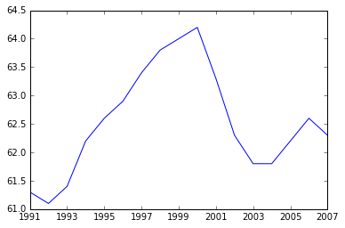

```python
employment_country.plot()
```

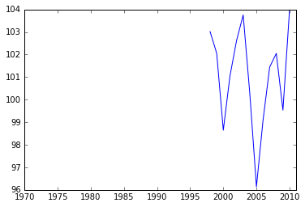

```python
female_completion_country.plot()
```

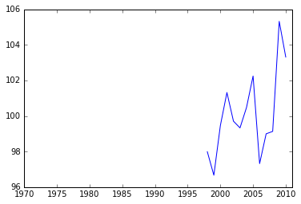

```python
male_completion_country.plot()
```

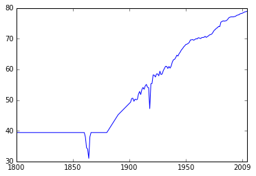

```python
life_expectancy_country.plot()
```

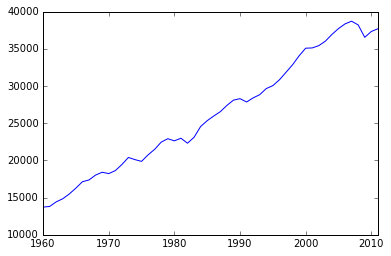

```python
gdp_per_capita_country.plot()
```